# Chapter 9 Outline

Alan T. Arnholt

2/13/2018

# 1 Introduction

## 1.1 Concepts

- Null hypothesis: Accepted as true, assuming a normal distribution from that data
- Alternative hypothesis
  - lower one-sided
  - upper one-sided
  - two-sided

When a hypothesis uniquely specifies the distribution for the population from which the sample is taken, the hypothesis is said to be **simple**. Any hypothesis that is not a simple hypothesis is called a **composite hypothesis**.

## 1.2 Type I and Type II Errors

- $\alpha = P(\text{type I error}) = P(\text{reject } H_0|H_0 \text{ is true})$ “Significance Level”
- $\beta = P(\text{type II error}) = P(\text{fail to reject }H_0|H_0 \text{ is false})$
- $1 - \beta = \text{Power of the Test}$

Power: probability you reject the null hypothesis when it’s false.

Fail to reject the null the only mistake you can make is type 2, if reject the null the only type of mistake you can make is type 1 (null hypothesis is true but reject “innocent yet claim guilty”).

### 1.2.1 Exercise

Given a **normal distribution** (need to know this) with unknown mean $\mu$ and know standard deviation $\sigma = 1$, one wishes to test the null hypothesis $H_0: \mu = 10$ versus the alternative hypothesis $H_1: \mu = 13$. A sample of size one is taken where the rejection region is considered to be the interval $(11.64485, \infty)$. Determine $\alpha$ and $\beta$ for this experiment. Graph $\alpha$ and $\beta$ by hand and with `R`.

**Solution**

```r
alpha <-1 - pnorm(11.64485, 10, 1)
## or pnorm(11.64485, 10, 1, lower.tail = FALSE)
beta <- pnorm(11.64485, 13, 1)
c(alpha, beta)
```

```
[1] 0.05000037 0.08768489
```

- Graph

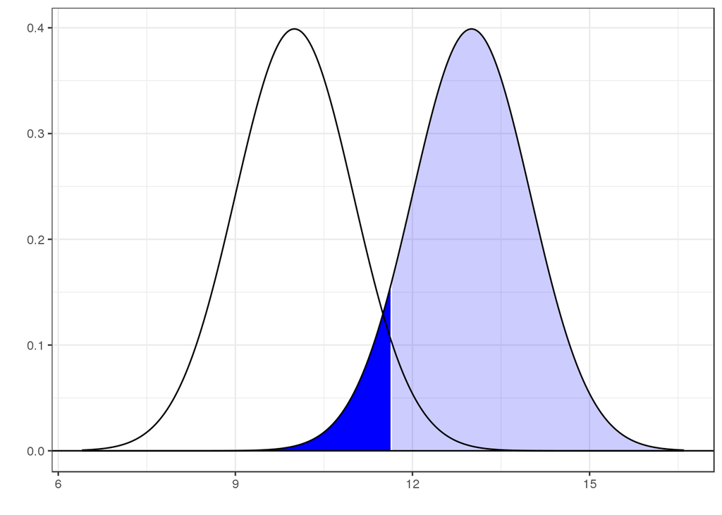

```r
library(ggplot2)
p <- ggplot(data = data.frame(x = c(6.4, 16.6)), aes(x = x))
## 3.6 standard deviations from each mean on each end for x values

dnorm_func <- function(x){
  y <- dnorm(x, 13, 1)
  y[x <= qnorm(0.95, 10, 1)] <- NA
  return(y)
}

dnorm_func1 <- function(x){
   y <- dnorm(x, 13, 1)
  y[x >= qnorm(0.95, 10, 1)] <- NA
  return(y)
}

dnorm_func2 <- function(x){
    y <- dnorm(x, 10, 1)
  y[x < qnorm(0.95, 10, 1)] <- NA
  return(y)
}

p + stat_function(fun = dnorm_func, geom = "area", fill = "blue", alpha = 0.2, n = 500) +
  stat_function(fun = dnorm_func1, geom = "area", fill = "blue", n = 500) +
  geom_hline(yintercept = 0)+
  stat_function(fun = dnorm, args = list(10, 1), n = 500)+
  stat_function(fun = dnorm, args = list(13, 1), n = 500)+
  theme_bw()+
  labs(x = "", y = "")
```

### 1.2.2 Exercise

Using a 10% significance level, what is the power of the test $H_0: \mu = 100$ versus $H_1: \mu > 100$ if a sample of size 25 is taken from a $N(105, 10)$?

```r
z <- qnorm(.1, 100, 10/sqrt(25), lower.tail = FALSE)
## or qnorm(.9, 100, 10/sqrt(25))
beta <- pnorm(z, 105, 10/sqrt(25))
POWER <- 1 - beta
POWER
```

```
[1] 0.8884732
```

- Write a function (one per group–Creating functions is discussed on page 74) that shades Type II error as well as the Power for a particular simple alternative hypothesis. This function will be used in your shiny app next week.

Quiz

## 1.3 Plotting Coverage Probability

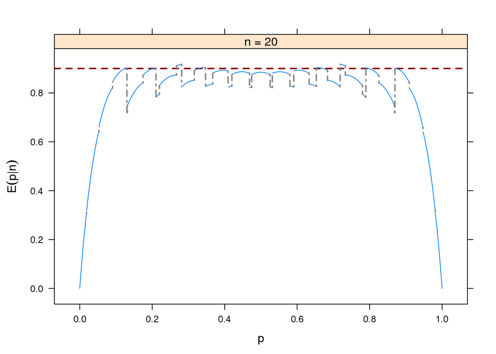

```r
library(binom)
binom.plot(n = 20, method = binom.asymp, np = 2000, conf.level = 0.90)
```

- What would you want the UI to look like for a coverage probability shiny app?
- Group assignment (develop a coverage probability shiny app).
- Upload the two directories (`BuildingWebappsWithShiny`, `CaseStudies`) in asulearn to your team/private repository.